# **Train and validate the CNN model from scratch**

```python
# Code to test if GPUs are available
import os
os.environ['TF_CPP_MIN_LOG_LEVEL'] = '3'
import tensorflow as tf

# Check TensorFlow version
print("TensorFlow version:", tf.__version__)

# List available physical devices
gpus = tf.config.list_physical_devices('GPU')
print("Num GPUs Available:", len(gpus))
print("GPU Details:", gpus)
```

```
TensorFlow version: 2.14.0
Num GPUs Available: 2
GPU Details: [PhysicalDevice(name='/physical_device:GPU:0', device_type='GPU'), PhysicalDevice(name='/physical_device:GPU:1', device_type='GPU')]
```

```python
# ================================
# System & Core Libraries
# ================================
import os
import random
import numpy as np
import cv2
from glob import glob
from collections import Counter, defaultdict

# ================================
# TensorFlow / Keras - Model Building & Training
# ================================
import tensorflow as tf
from tensorflow.keras.models import Model, Sequential, load_model
from tensorflow.keras.layers import (
    Conv2D, MaxPooling2D, Flatten, Dense,
    Dropout, Activation, GlobalAveragePooling2D
)
from tensorflow.keras.applications import ResNet50, MobileNetV2, EfficientNetB0
from tensorflow.keras.applications.resnet50 import preprocess_input as resnet_preprocess
from tensorflow.keras.applications.mobilenet_v2 import preprocess_input as mobilenet_preprocess
from tensorflow.keras.applications.efficientnet import preprocess_input as efficientnet_preprocess
from tensorflow.keras.optimizers import Adam, SGD
from tensorflow.keras.callbacks import EarlyStopping, ModelCheckpoint
from tensorflow.keras.preprocessing.image import ImageDataGenerator, load_img, img_to_array
from tensorflow.keras.preprocessing import image_dataset_from_directory
# ================================
# Vision Transformer (ViT) Specific
# ================================
from vit_keras import vit, utils

# ================================
# Scikit-learn - Metrics & Utilities
# ================================
from sklearn.utils import class_weight
from sklearn.metrics import (
    classification_report, confusion_matrix, accuracy_score,
    roc_curve, auc, precision_recall_curve, f1_score, roc_auc_score
)

# ================================
# Visualization & Progress
# ================================
import matplotlib.pyplot as plt
import seaborn as sns
from tqdm import tqdm

# ================================
# Jupyter/IPython Utilities
# ================================
%matplotlib inline
```

```python
HEIGHT = 224
WIDTH = 224
```

```python
# Step up two folders from current working directory, then into DATA/archive/train
TRAIN_DIR = os.path.abspath(os.path.join("..", "..", "DATA", "archive", "train"))
BATCH_SIZE = 32

train_datagen = ImageDataGenerator(
    rescale=1./255,
    rotation_range=90,
    horizontal_flip=True,
    vertical_flip=True
)

train_generator = train_datagen.flow_from_directory(
    TRAIN_DIR,
    target_size=(HEIGHT, WIDTH),
    batch_size=BATCH_SIZE,
    class_mode='binary'
)
```

```
Found 8503 images belonging to 2 classes.
```

```python
# Navigate to the validation folder relative to current script location
VALID_DIR = os.path.abspath(os.path.join("..", "..", "DATA", "archive", "valid"))

valid_datagen = ImageDataGenerator(
    rescale=1./255
)
validation_generator = valid_datagen.flow_from_directory(
    VALID_DIR,
    target_size=(HEIGHT, WIDTH),
    batch_size=BATCH_SIZE,
    class_mode='binary'
)
```

```
Found 2424 images belonging to 2 classes.
```

# ***Train model from scratch. As I have already trained the model and saved as "full_model.keras"

# No need to run this code again***

```python
# === Hyperparameters ===
batch_size = 32
epochs = 10
input_shape = (HEIGHT, WIDTH, 3)  # make sure HEIGHT and WIDTH are defined globally

# === Build the Model ===
model = Sequential([
    Conv2D(32, (3, 3), input_shape=input_shape),
    Activation('relu'),
    MaxPooling2D(pool_size=(2, 2)),

    Conv2D(32, (3, 3)),
    Activation('relu'),
    MaxPooling2D(pool_size=(2, 2)),

    Conv2D(64, (3, 3)),
    Activation('relu'),
    MaxPooling2D(pool_size=(2, 2)),

    Flatten(),
    Dense(64),
    Activation('relu'),
    Dropout(0.5),
    Dense(1),
    Activation('sigmoid')
])

model.compile(
    loss='binary_crossentropy',
    optimizer=Adam(learning_rate=1e-4),
    metrics=['accuracy']
)

model.summary()

# === Callbacks ===
model_checkpoint = ModelCheckpoint(
    filepath="best_weights.keras",
    save_best_only=True,
    monitor='val_loss',
    mode='min',
    verbose=1,
    save_weights_only=True
)

early_stopping = EarlyStopping(
    monitor='val_loss',
    patience=3,
    restore_best_weights=True,
    verbose=1
)

callbacks = [early_stopping, model_checkpoint]

# === Compute Class Weights from Training Data ===
class_weights = class_weight.compute_class_weight(
    class_weight='balanced',
    classes=np.unique(train_generator.classes),
    y=train_generator.classes
)
class_weights_dict = dict(enumerate(class_weights))
print(f"Class weights used: {class_weights_dict}")

# === Train the Model ===
scratch_hist = model.fit(
    train_generator,
    epochs=epochs,
    validation_data=validation_generator,
    callbacks=callbacks,
    class_weight=class_weights_dict
)

# === Save Full Model Manually ===
model.save("full_model.keras")
```

```
Model: "sequential"
_________________________________________________________________
 Layer (type)                Output Shape              Param #
=================================================================
 conv2d (Conv2D)             (None, 222, 222, 32)      896

 activation (Activation)     (None, 222, 222, 32)      0

 max_pooling2d (MaxPooling2  (None, 111, 111, 32)      0
 D)

 conv2d_1 (Conv2D)           (None, 109, 109, 32)      9248

 activation_1 (Activation)   (None, 109, 109, 32)      0

 max_pooling2d_1 (MaxPoolin  (None, 54, 54, 32)        0
 g2D)

 conv2d_2 (Conv2D)           (None, 52, 52, 64)        18496

 activation_2 (Activation)   (None, 52, 52, 64)        0

 max_pooling2d_2 (MaxPoolin  (None, 26, 26, 64)        0
 g2D)

 flatten (Flatten)           (None, 43264)             0

 dense (Dense)               (None, 64)                2768960

 activation_3 (Activation)   (None, 64)                0

 dropout (Dropout)           (None, 64)                0

 dense_1 (Dense)             (None, 1)                 65

 activation_4 (Activation)   (None, 1)                 0

=================================================================
Total params: 2797665 (10.67 MB)
Trainable params: 2797665 (10.67 MB)
Non-trainable params: 0 (0.00 Byte)
_________________________________________________________________
Class weights used: {0: 2.4391853126792884, 1: 0.6289201183431953}
Epoch 1: val_loss improved from inf to 0.31825, saving model to best_weights.keras
Epoch 2: val_loss improved from 0.31825 to 0.29384, saving model to best_weights.keras
Epoch 3: val_loss did not improve from 0.29384
Epoch 4: val_loss improved from 0.29384 to 0.27854, saving model to best_weights.keras
Epoch 5: val_loss did not improve from 0.27854
Epoch 6: val_loss improved from 0.27854 to 0.24794, saving model to best_weights.keras
Epoch 7: val_loss did not improve from 0.24794
Epoch 8: val_loss did not improve from 0.24794

Epoch 9: val_loss did not improve from 0.24794
Epoch 9: early stopping
```

```python
# === Save Full Model Manually ===
model.save("full_model.keras")
```

### CNN Training Progress Summary

[output not shown]

- **Best Validation Loss**: **Epoch 6** with **val_loss = 0.2479**, **val_accuracy = 85.27%**
- **EarlyStopping**: Triggered after **Epoch 9** due to no improvement in validation loss from the best recorded at Epoch 6 (patience = 3)

### Summary:

# === **Plot Accuracy & Loss Curves** ===

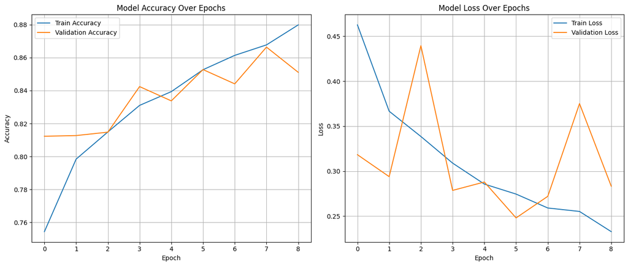

```python
# === Plot Accuracy & Loss Curves ===
plt.figure(figsize=(14, 6))

# Accuracy Plot
plt.subplot(1, 2, 1)
plt.plot(scratch_hist.history['accuracy'], label='Train Accuracy')
plt.plot(scratch_hist.history['val_accuracy'], label='Validation Accuracy')
plt.title('Model Accuracy Over Epochs')
plt.xlabel('Epoch')
plt.ylabel('Accuracy')
plt.grid(True)
plt.legend()

# Loss Plot
plt.subplot(1, 2, 2)
plt.plot(scratch_hist.history['loss'], label='Train Loss')
plt.plot(scratch_hist.history['val_loss'], label='Validation Loss')
plt.title('Model Loss Over Epochs')
plt.xlabel('Epoch')
plt.ylabel('Loss')
plt.grid(True)
plt.legend()

plt.tight_layout()
plt.show()
```

### CNN Training Summary from Accuracy & Loss Curves

[output not shown]

## **Model prediction on validation dataset**

```python
# Load the full model
model = load_model("full_model.keras")
```

```python
model.summary()
```

```
Model: "sequential"
_________________________________________________________________
 Layer (type)                Output Shape              Param #
=================================================================
 conv2d (Conv2D)             (None, 222, 222, 32)      896

 activation (Activation)     (None, 222, 222, 32)      0

 max_pooling2d (MaxPooling2  (None, 111, 111, 32)      0
 D)

 conv2d_1 (Conv2D)           (None, 109, 109, 32)      9248

 activation_1 (Activation)   (None, 109, 109, 32)      0

 max_pooling2d_1 (MaxPoolin  (None, 54, 54, 32)        0
 g2D)

 conv2d_2 (Conv2D)           (None, 52, 52, 64)        18496

 activation_2 (Activation)   (None, 52, 52, 64)        0

 max_pooling2d_2 (MaxPoolin  (None, 26, 26, 64)        0
 g2D)

 flatten (Flatten)           (None, 43264)             0

 dense (Dense)               (None, 64)                2768960

 activation_3 (Activation)   (None, 64)                0

 dropout (Dropout)           (None, 64)                0

 dense_1 (Dense)             (None, 1)                 65

 activation_4 (Activation)   (None, 1)                 0

=================================================================
Total params: 2797665 (10.67 MB)
Trainable params: 2797665 (10.67 MB)
Non-trainable params: 0 (0.00 Byte)
_________________________________________________________________
```

# **Instead of trying thresholds by trial-error, we can plot Precision-Recall curve and ROC curve**

```
Found 8503 images belonging to 2 classes.
Best Threshold: 0.22 | Best F1-Score: 0.9413
```

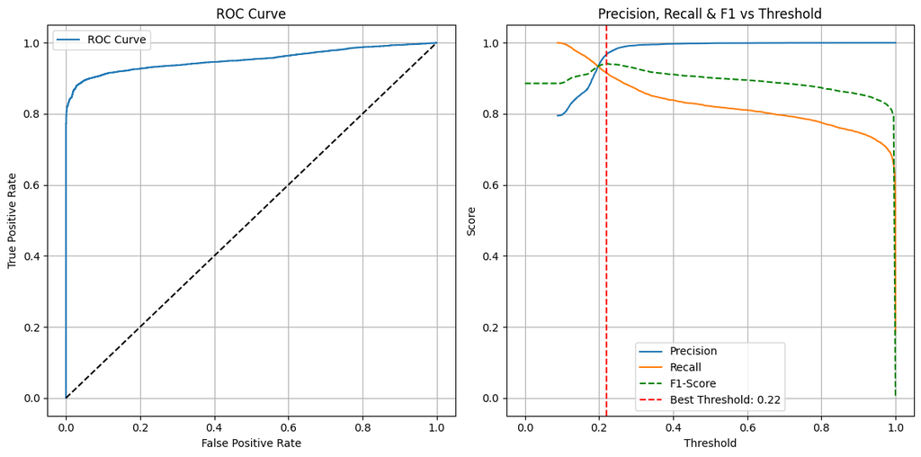

```python
# Constants
TRAIN_DIR = os.path.abspath(os.path.join("..", "..", "DATA", "archive", "train"))
BATCH_SIZE = 32
WIDTH, HEIGHT = 224, 224  # Adjust as necessary

# Data generator
train_datagen = ImageDataGenerator(
    rescale=1./255,
    rotation_range=90,
    horizontal_flip=True,
    vertical_flip=True
)

train_generator = train_datagen.flow_from_directory(
    TRAIN_DIR,
    target_size=(HEIGHT, WIDTH),
    batch_size=BATCH_SIZE,
    class_mode='binary',
    shuffle=False  # Important for matching predictions with labels
)

# Make predictions
model = load_model("full_model.keras")
predictions = model.predict(train_generator, verbose=1)
predicted_probs = predictions.squeeze()  # Flatten array if necessary

# True labels
ground_truth = train_generator.classes

# Compute F1 scores across thresholds
thresholds = np.linspace(0, 1, 200)
f1_scores = [f1_score(ground_truth, predicted_probs > t) for t in thresholds]
best_idx = np.argmax(f1_scores)
best_threshold = thresholds[best_idx]
best_f1 = f1_scores[best_idx]

print(f"Best Threshold: {best_threshold:.2f} | Best F1-Score: {best_f1:.4f}")

# Plot ROC Curve
fpr, tpr, roc_thresh = roc_curve(ground_truth, predicted_probs)
plt.figure(figsize=(12, 6))
plt.subplot(1, 2, 1)
plt.plot(fpr, tpr, label="ROC Curve")
plt.plot([0, 1], [0, 1], 'k--')
plt.xlabel("False Positive Rate")
plt.ylabel("True Positive Rate")
plt.title("ROC Curve")
plt.legend()
plt.grid(True)

# Plot Precision-Recall Curve
precision, recall, pr_thresh = precision_recall_curve(ground_truth, predicted_probs)
plt.subplot(1, 2, 2)
plt.plot(pr_thresh, precision[:-1], label="Precision")
plt.plot(pr_thresh, recall[:-1], label="Recall")
plt.plot(thresholds, f1_scores, linestyle="--", color="green", label="F1-Score")

# Vertical line for best threshold
plt.axvline(x=best_threshold, color='red', linestyle='--', label=f'Best Threshold: {best_threshold:.2f}')
plt.xlabel("Threshold")
plt.ylabel("Score")
plt.title("Precision, Recall & F1 vs Threshold")
plt.legend()
plt.grid(True)
plt.tight_layout()
plt.show()
```

# **Analysis of Model Performance Based on Precision-Recall and ROC Curves**

Our model shows promising results, indicated by the shape of both the ROC and Precision-Recall curves. The best F1-score is 0.9413, suggesting effective performance in distinguishing between the classes.

### **ROC Curve Analysis:**

- The ROC curve approaches the top-left corner, which signifies a high true positive rate and a low false positive rate, indicative of a strong classifier.

### **Is 0.22 a realistic threshold?**

- Yes, if the model outputs probabilities that are well-calibrated and early prediction is crucial, a threshold of 0.22 ensures that predictions are made with a reasonable balance of precision and recall.
- This threshold is particularly useful if avoiding false negatives is more critical than minimizing false positives, as it favors sensitivity over specificity.

### **When to Use a Lower Threshold (e.g., 0.22):**

[output not shown]

This comprehensive approach provides a clear pathway for applying the model in real-world scenarios, especially where balancing the sensitivity and specificity is key.

# **What is Precision in this case?**

### Precision = Of all the images the model predicted as Occupied, how many were actually Occupied?

### High precision means few false alarms. (i.e., the model doesn’t wrongly say “occupied” when it’s actually empty.)

# **When should we try to maximize precision?**

### We want to trust the model's “occupied” prediction.

### We want to avoid blocking spots that are actually empty.

# **What is Recall in this case?**

### Recall = Of all the actual Occupied spots, how many did the model correctly detect?

### High recall means few misses. (i.e., the model doesn’t miss cars that are actually there.)

# **When should we try to maximize Recall?**

### We want to detect all cars, even at the cost of some false alarms.

### We are trying to track occupancy levels accurately.'

### We want to avoid saying “empty” when a car is there

# **In Real-World Use:**

### If our app shows drivers where to park → recall is more important (so they don’t go to an already-occupied spot).

### If our app enforces rules (e.g., penalties for occupying unauthorized spots) → precision is more important (avoid false accusations).

# Summary

### Threshold Tradeoff in Parking Lot Classification

### Threshold Tradeoff in Parking Lot Classification

[output not shown]

# **Evalution On validation set using thresholds 0.22**

```
Total validation images found: 2424
```

```
100%|█████████████████████████████████████████████████████████████████████████████████████████████████████████████████████████████████████████████████| 2424/2424 [02:04<00:00, 19.53it/s]
```

```
Classification Report:
              precision    recall  f1-score   support

       Empty       0.67      0.44      0.53       457
    Occupied       0.88      0.95      0.91      1967

    accuracy                           0.85      2424
   macro avg       0.77      0.69      0.72      2424
weighted avg       0.84      0.85      0.84      2424
```

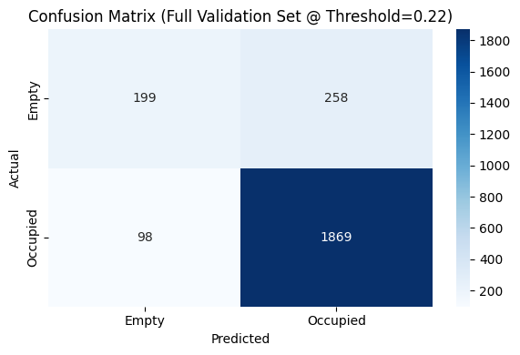

```
Confusion matrix:
[[ 199  258]
 [  98 1869]]
Overall Accuracy: 85.31%
```

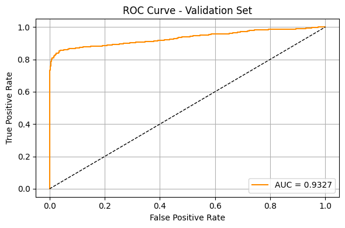

```
AUC-ROC Score: 0.9327
```

```python
# === Paths and Config ===
HEIGHT = 224
WIDTH = 224
THRESHOLD = 0.22
valid_base_dir = os.path.abspath(os.path.join("..", "..", "DATA", "archive", "valid"))

occupied_dir = os.path.join(valid_base_dir, "occupied", "*.jpg")
empty_dir = os.path.join(valid_base_dir, "empty", "*.jpg")

# === Load All Validation Images ===
full_valid_images = glob(occupied_dir) + glob(empty_dir)
print(f"Total validation images found: {len(full_valid_images)}")

# === Load the Saved Model ===
model = load_model("full_model.keras")

# === Predict on Full Validation Set ===
full_ground_truth = []
full_pred_probs = []
full_predictions = []

for img in tqdm(full_valid_images):
    label = os.path.basename(os.path.dirname(img)).lower()
    full_ground_truth.append(1 if label == "occupied" else 0)

    image = cv2.imread(img)
    image = cv2.cvtColor(image, cv2.COLOR_BGR2RGB)
    image = cv2.resize(image, (WIDTH, HEIGHT))
    image_x = np.expand_dims(image, axis=0)
    image_x = image_x.astype(np.float32) / 255.0  # Use correct preprocessing

    prob = model.predict(image_x, verbose=0).squeeze()
    full_pred_probs.append(prob)
    full_predictions.append(1 if prob > THRESHOLD else 0)

# === Evaluation Metrics ===
print("\nClassification Report:")
print(classification_report(full_ground_truth, full_predictions, target_names=['Empty', 'Occupied'], zero_division=0))

# === Confusion Matrix ===
cm = confusion_matrix(full_ground_truth, full_predictions)
plt.figure(figsize=(6, 4))
sns.heatmap(cm, annot=True, fmt='d', cmap='Blues')
plt.title(f"Confusion Matrix (Full Validation Set @ Threshold={THRESHOLD})")
plt.xlabel("Predicted")
plt.ylabel("Actual")
plt.xticks(ticks=[0.5, 1.5], labels=['Empty', 'Occupied'])
plt.yticks(ticks=[0.5, 1.5], labels=['Empty', 'Occupied'])
plt.tight_layout()
plt.show()

print("\nConfusion matrix:")
print(cm)

# === Overall Accuracy ===
acc = accuracy_score(full_ground_truth, full_predictions)
print(f"Overall Accuracy: {acc:.2%}")

# === ROC-AUC Curve ===
from sklearn.metrics import roc_curve, roc_auc_score

fpr, tpr, thresholds_roc = roc_curve(full_ground_truth, full_pred_probs)
auc_score = roc_auc_score(full_ground_truth, full_pred_probs)

plt.figure(figsize=(6, 4))
plt.plot(fpr, tpr, label=f"AUC = {auc_score:.4f}", color='darkorange')
plt.plot([0, 1], [0, 1], 'k--', lw=1)
plt.xlabel("False Positive Rate")
plt.ylabel("True Positive Rate")
plt.title("ROC Curve - Validation Set")
plt.legend(loc="lower right")
plt.grid(True)
plt.tight_layout()
plt.show()

print(f"AUC-ROC Score: {auc_score:.4f}")
```